# Decision Tree vs SVM

A light exercise in EDA and classification methods comparison

Hendrik A. Dreyer

28 September 2019

## Introduction

This paper is about the evaluation and comparison of two classification methods as implemented by our friends, The Decision Tree and The Support Vector Machine. We will be seeking a binary classification outcome to predict whether the stay of a patient is three days or less, or more than three days at a Melbourne hospital.

## The Data

As they say, it’s all about the data. In this study we are looking at a data set which contains observations of all Emergency Surgery admissions between February 2011 and December 2017 at a Melbourne super-specialty hospital. The data set, same as some of the patients in it, has several problems and issues.

After loading the data set into the usual R-flavored data frame we source the dimensions of it.

```r
dim(ER_df)
```

```
## [1] 15297    24
```

The data set contains 15297 observations and 24 features. A quick peak under the hood of ER_df reveals the following horrors.

```r
library(tidyverse)
glimpse(ER_df)
```

```
## Observations: 15,297
## Variables: 24
## $ MatchIPM                 <int> 0, 1, 1, 1, 0, 1, 0, 1, 1, 1, 0, 1, 1...
## $ Patient_Num              <int> 2514, 3507, 1867, 1019, 1276, 3603, 5...
## $ MHAdmissionDate          <fct> 19-Mar-10, 8-Feb-11, 19-Feb-11, 20-Fe...
## $ DischargeDate            <fct> 18-Jun-11, 8-Mar-11, 25-Feb-11, 21-Fe...
## $ LOS                      <int> 456, 28, 6, 1, 1, 2, 4, 1, 0, 2, 3, 2...
## $ LOS_cat                  <int> 1, 1, 1, 0, 0, 0, 1, 0, 0, 0, 0, 0, 0...
## $ Gender                   <fct> M, M, M, M, M, F, F, F, F, F, F, M, M...
## $ AdmissionAge             <int> 55, 85, 53, 47, 83, 46, 60, 71, 53, 8...
## $ Age60Plus                <int> 0, 1, 0, 0, 1, 0, 1, 1, 0, 1, 0, 0, 0...
## $ Death                    <int> 0, 0, 0, 0, 0, 0, 0, 0, 0, 0, 0, 0, 0...
## $ AdmissionType            <fct> Emergency, Emergency, Emergency, Emer...
## $ Outcome                  <fct> NULL, Rehabilitation, Inpatient, Home...
## $ GenSurg_LOS              <int> 0, 28, 6, 1, 1, 2, 4, 1, 0, 2, 3, 2, ...
## $ MH_LOS                   <int> 456, 28, 6, 1, 1, 2, 4, 1, 0, 2, 3, 2...
## $ DiagnosisText            <fct> Constipation, Constipation, Rectal Fo...
## $ DiseaseProcess           <fct> NULL, NULL, Trauma, Inflammatory, Inf...
## $ BodySystem               <fct> NULL, NULL, Lower GI, Hepatobiliary, ...
## $ Operative                <int> 0, 0, 0, 0, 0, 1, 1, 0, 0, 0, 0, 1, 1...
## $ Complications            <int> 0, 0, 0, 0, 0, 0, 0, 0, 0, 0, 0, 0, 0...
## $ Endoscopic               <int> 0, 0, 0, 0, 0, 0, 0, 0, 0, 0, 0, 0, 0...
## $ OperationId              <fct> NULL, NULL, NULL, NULL, NULL, 43, 59,...
## $ OperationCategory        <fct> NULL, NULL, NULL, NULL, NULL, ABDOMIN...
## $ OperationProcedure       <fct> NULL, NULL, NULL, NULL, NULL, Major v...
## $ OperationDescriptionText <fct> NULL, NULL, NULL, NULL, NULL, Para-um...
```

A closer inspection into those values labelled NULL, reveals that they are not true-blue NAs. No, they are strings. And, for that reason our trusty old method of detecting and counting NAs fails miserably as illustrated by the following step:

```r
sapply(ER_df, function(x) sum(is.na(x)))
```

```
##                 MatchIPM              Patient_Num          MHAdmissionDate
##                        0                        0                        0
##            DischargeDate                      LOS                  LOS_cat
##                        0                        0                        0
##                   Gender             AdmissionAge                Age60Plus
##                        0                        0                        0
##                    Death            AdmissionType                  Outcome
##                        0                        0                        0
##              GenSurg_LOS                   MH_LOS            DiagnosisText
##                        0                        0                        0
##           DiseaseProcess               BodySystem                Operative
##                        0                        0                        0
##            Complications               Endoscopic              OperationId
##                        0                        0                        0
##        OperationCategory       OperationProcedure OperationDescriptionText
##                        0                        0                        0
```

Armed with that bit of insight we can now deliberately search for the words “NULL”, “Null” and "". From there, we can replace them with proper NAs.

```r
ER_df[ER_df=="NULL"] <- NA
ER_df[ER_df=="Null"] <- NA
ER_df[ER_df==""]     <- NA
```

Running our NA detection code again identifies the true situation regarding NAs in this data set.

```r
sapply(ER_df, function(x) sum(is.na(x)))
```

```
##                 MatchIPM              Patient_Num          MHAdmissionDate
##                        0                        0                        0
##            DischargeDate                      LOS                  LOS_cat
##                        0                        0                        0
##                   Gender             AdmissionAge                Age60Plus
##                        0                        0                        0
##                    Death            AdmissionType                  Outcome
##                        0                        0                    10864
##              GenSurg_LOS                   MH_LOS            DiagnosisText
##                        0                        0                        0
##           DiseaseProcess               BodySystem                Operative
##                    12538                    13377                        0
##            Complications               Endoscopic              OperationId
##                        0                        0                    10175
##        OperationCategory       OperationProcedure OperationDescriptionText
##                    10175                    10175                    10175
```

From the above output we observe that Outcome, OperationId, OperationDescriptionText, OperationProcedure, BodySystem, DiseaseProcess and OperationCategory all contains more than 10000 NAs. Imputing these dimensions would be a waste of time and can therefore be omitted from the data set as they do not contribute any substantial information to the variance of the data.  
Without any further ado, let’s get rid of them.

```r
ER_df <- ER_df[,-which(names(ER_df) %in% c("Outcome",
                                           "OperationId",
                                           "OperationDescriptionText",
                                           "OperationProcedure",
                                           "BodySystem",
                                           "DiseaseProcess",
                                           "OperationCategory"))]
```

Let’s have a look at the number of levels for each of the categorical variables in the remaining data set.

```r
str(ER_df)
```

```
## 'data.frame':    15297 obs. of  17 variables:
##  $ MatchIPM       : int  0 1 1 1 0 1 0 1 1 1 ...
##  $ Patient_Num    : int  2514 3507 1867 1019 1276 3603 5866 2289 3220 4067 ...
##  $ MHAdmissionDate: Factor w/ 2491 levels "1-Apr-11","1-Apr-12",..: 862 2348 835 1001 1001 1001 1001 1082 1082 1082 ...
##  $ DischargeDate  : Factor w/ 2492 levels "1-Apr-11","1-Apr-12",..: 775 2376 1410 1082 1082 1164 1328 1164 1082 1245 ...
##  $ LOS            : int  456 28 6 1 1 2 4 1 0 2 ...
##  $ LOS_cat        : int  1 1 1 0 0 0 1 0 0 0 ...
##  $ Gender         : Factor w/ 2 levels "F","M": 2 2 2 2 2 1 1 1 1 1 ...
##  $ AdmissionAge   : int  55 85 53 47 83 46 60 71 53 81 ...
##  $ Age60Plus      : int  0 1 0 0 1 0 1 1 0 1 ...
##  $ Death          : int  0 0 0 0 0 0 0 0 0 0 ...
##  $ AdmissionType  : Factor w/ 4 levels "Day Procedure",..: 3 3 3 3 3 3 3 3 3 3 ...
##  $ GenSurg_LOS    : int  0 28 6 1 1 2 4 1 0 2 ...
##  $ MH_LOS         : int  456 28 6 1 1 2 4 1 0 2 ...
##  $ DiagnosisText  : Factor w/ 3705 levels " Acute appendicitis",..: 938 938 2832 511 690 1476 461 225 259 225 ...
##  $ Operative      : int  0 0 0 0 0 1 1 0 0 0 ...
##  $ Complications  : int  0 0 0 0 0 0 0 0 0 0 ...
##  $ Endoscopic     : int  0 0 0 0 0 0 0 0 0 0 ...
```

From the 17 features left, after the above culling, we observe that MatchIPM and Patient_Num are both two indexes, which does not say anything of value re. the length of stay of the patient or about the physical state of the patient. The factors MHAdmissionDate, DischargeDate and DiagnosisText all have extra-ordinary high numbers of unique values. The number of permutations needed to fit a categorical feature is equal to 2^N, where N is the number of unique levels. Therefore, any categorical feature with more than 52 levels are removed from the data set. I feel obliged to leave in the DischargeDate feature for now as it might tell us something about the time frame in which the patients were submitted. Therefore, we only get rid of the other two along with MatchIPM and Patient_Num.

```r
ER_df <- ER_df[,-which(names(ER_df) %in% c("MatchIPM",
                                           "Patient_Num",
                                           "MHAdmissionDate",
                                           "DiagnosisText"))]
```

A quick inspection of GenSurg_LOS (Length of stay directly associated with surgery) reveals the following fly in the ointment.

```r
unique(ER_df$GenSurg_LOS)
```

```
##  [1]    0   28    6    1    2    4    3   11    7    8   10    5   13   -9
## [15]  -11   15   12    9   16  -16   17   30   92   21   22   27   14   94
## [29]   19   18   20   43   73   25   36   23   -2   26   24   32   41   31
## [43]   48   -1   70   44   35 -323   96 -298  -10   29   -3   -5 -101  -14
## [57] -319 -280  -73  -15 -119 -325   37   57 -146 -200   40   53  -23   71
## [71] -336   39  -13   78   33   42   47   50  -30  -81  -40  -25   72   97
## [85]  -54 -293  -64  -44  -87   60  -47
```

Those negative numbers for GenSurg_LOS are disturbing. Obviously something has gone wrong in the data and therefore GenSurg_LOS is unusable (as it is impossible to stay -323 days at the hospital. Many have tried but, they failed).  
Further we find that both the features LOS and MH_LOS describes the same feature - length of stay. Length of stay is directly correlated with our anticipated binary response variable, which will indicate a stay at the hospital of less than or equal to three days, or more than three days. Therefore, we need to cull both LOS and MH_LOS.

```r
ER_df <- ER_df[,-which(names(ER_df) %in% c("GenSurg_LOS",
                                           "LOS",
                                           "MH_LOS"))]
```

From the DischargeDate we can extract three additional features: Year, Month and Weekday. This might tell us something about the level of service that might impact the stay of a patient during specific time frames in a week, month or year. Who knows, let’s see.

```r
library(lubridate)
ER_df$DischargeDate         <- as.Date(ER_df$DischargeDate,   format = "%d-%b-%y")
ER_df$DischargeDate_Year    <- as.factor(year(ymd(ER_df$DischargeDate)))
ER_df$DischargeDate_Month   <- as.factor(month(ymd(ER_df$DischargeDate)))
ER_df$DischargeDate_Weekday <- as.factor(weekdays(ymd(ER_df$DischargeDate)))
```

Now we can also discard of DischargeDate all together.

```r
ER_df <- ER_df[,-which(names(ER_df) %in% c("DischargeDate"))]
```

Upon further inspection we find that a number of the features are actually binary coded categorical variables such as, Death, Age60Plus, Gender, Operative, Complications and Endoscopic. We’ll convert these to proper factors.

```r
ER_df$LOS_cat       <- as.factor(ER_df$LOS_cat)
ER_df$Age60Plus     <- as.factor(ER_df$Age60Plus)
ER_df$Death         <- as.factor(ER_df$Death)
ER_df$Operative     <- as.factor(ER_df$Operative)
ER_df$Complications <- as.factor(ER_df$Complications)
ER_df$Endoscopic    <- as.factor(ER_df$Endoscopic)
```

Lastly, let’s re-check for any NAs

```r
sapply(ER_df, function(x) sum(is.na(x)))
```

```
##               LOS_cat                Gender          AdmissionAge
##                     0                     0                     0
##             Age60Plus                 Death         AdmissionType
##                     0                     0                     0
##             Operative         Complications            Endoscopic
##                     0                     0                     0
##    DischargeDate_Year   DischargeDate_Month DischargeDate_Weekday
##                     0                     0                     0
```

Et, voila! No NAs!  
Ok, let’s take a breather, step back and see what our manicured data set looks like now.

```r
str(ER_df)
```

```
## 'data.frame':    15297 obs. of  12 variables:
##  $ LOS_cat              : Factor w/ 2 levels "0","1": 2 2 2 1 1 1 2 1 1 1 ...
##  $ Gender               : Factor w/ 2 levels "F","M": 2 2 2 2 2 1 1 1 1 1 ...
##  $ AdmissionAge         : int  55 85 53 47 83 46 60 71 53 81 ...
##  $ Age60Plus            : Factor w/ 2 levels "0","1": 1 2 1 1 2 1 2 2 1 2 ...
##  $ Death                : Factor w/ 2 levels "0","1": 1 1 1 1 1 1 1 1 1 1 ...
##  $ AdmissionType        : Factor w/ 4 levels "Day Procedure",..: 3 3 3 3 3 3 3 3 3 3 ...
##  $ Operative            : Factor w/ 2 levels "0","1": 1 1 1 1 1 2 2 1 1 1 ...
##  $ Complications        : Factor w/ 2 levels "0","1": 1 1 1 1 1 1 1 1 1 1 ...
##  $ Endoscopic           : Factor w/ 2 levels "0","1": 1 1 1 1 1 1 1 1 1 1 ...
##  $ DischargeDate_Year   : Factor w/ 7 levels "2011","2012",..: 1 1 1 1 1 1 1 1 1 1 ...
##  $ DischargeDate_Month  : Factor w/ 12 levels "1","2","3","4",..: 6 3 2 2 2 2 2 2 2 2 ...
##  $ DischargeDate_Weekday: Factor w/ 7 levels "Friday","Monday",..: 3 6 1 2 2 6 5 6 2 7 ...
```

## Method

This sections reveals my ad hoc methods in terms of applying a couple of classification methods. Firts, let’s randomly split the data into a training set and a testing set at a 70:30 ratio.

```r
set.seed(1489)
training_ind <- sample(dim(ER_df)[1], size = (0.7*dim(ER_df)[1]))
train_set <- ER_df[ training_ind,];
test_set  <- ER_df[-training_ind,];
```

The 70:30 ratio split results in the following:

```r
dim(train_set)
```

```
## [1] 10707    12
```

```r
dim(test_set)
```

```
## [1] 4590   12
```

### Figure 1: tree_large

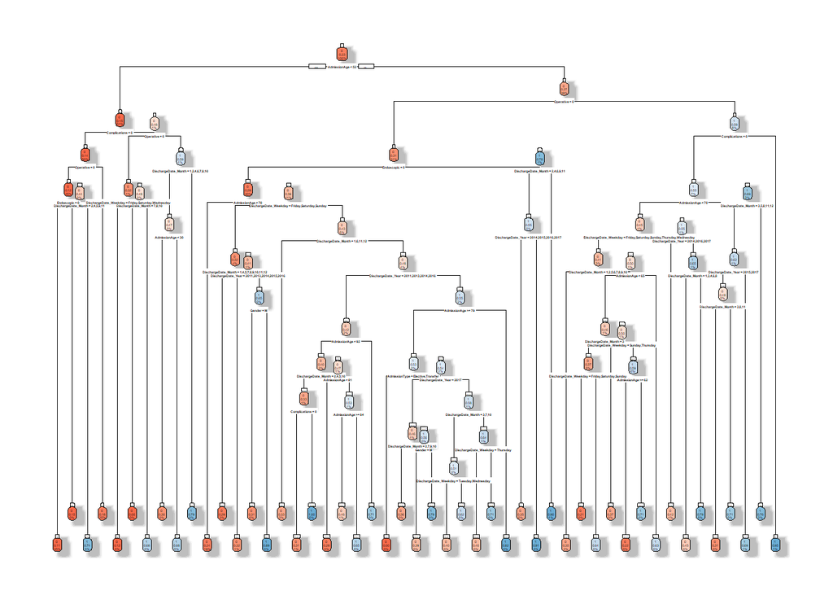

```r
library(rpart)
library(rpart.plot)
set.seed(1)
tree_large <- rpart(LOS_cat~.,
                    data     = train_set,
                    method   = "class",
                    parms    = list(split = "gini"),
                    control  = rpart.control(cp = 0.001, minsplit = 2))
rpart.plot(tree_large, box.palette="RdBu", shadow.col="gray", nn=TRUE)
```

### Figure 2: tree_medium

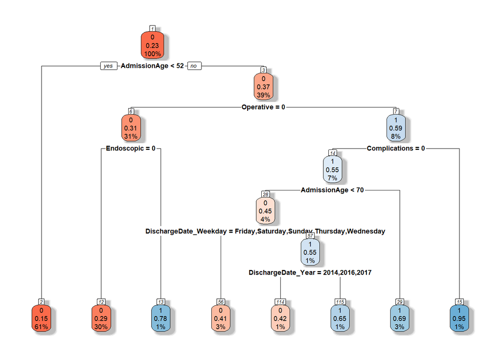

```r
set.seed(1)
tree_medium <- rpart(LOS_cat~.,
                    data     = train_set,
                    method   = "class",
                    parms    = list(split = "gini"),
                    control  = rpart.control(cp = 0.004, minsplit = 50))
rpart.plot(tree_medium, box.palette="RdBu", shadow.col="gray", nn=TRUE)
```

### Figure 3: tree_small

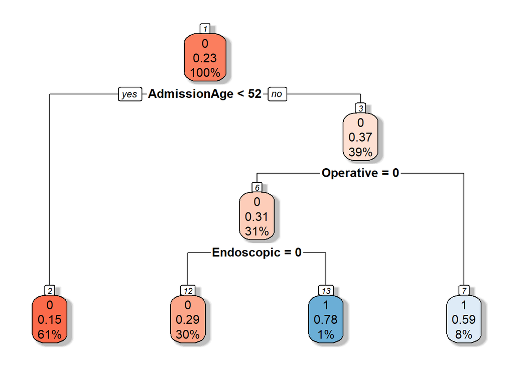

```r
set.seed(1)
tree_small <- rpart(LOS_cat~.,
                    data     = train_set,
                    method   = "class",
                    parms    = list(split = "gini"),
                    control  = rpart.control(cp = 0.01, minsplit = 20))
rpart.plot(tree_small, box.palette="RdBu", shadow.col="gray", nn=TRUE)
```

From the above three trees we can clearly observe that the last created decision tree, tree_small is by far the easiest to interpret. tree_medium ain’t too bad as it brings another layer of information to the user via the DischargeDate_Weekday that it adds to the tree. tree_large is too complex and frankly too small to read.

The buttery goodness of tree_medium will make me side with it. Let’s look at the summary for tree_medium.

```r
printcp(tree_medium)
```

```
##
## Classification tree:
## rpart(formula = LOS_cat ~ ., data = train_set, method = "class",
##     parms = list(split = "gini"), control = rpart.control(cp = 0.004,
##         minsplit = 50))
##
## Variables actually used in tree construction:
## [1] AdmissionAge          Complications         DischargeDate_Weekday
## [4] DischargeDate_Year    Endoscopic            Operative
##
## Root node error: 2512/10707 = 0.23461
##
## n= 10707
##
##          CP nsplit rel error  xerror     xstd
## 1 0.0308519      0   1.00000 1.00000 0.017455
## 2 0.0207006      2   0.93830 0.94029 0.017080
## 3 0.0097532      3   0.91760 0.91959 0.016944
## 4 0.0055732      5   0.89809 0.90366 0.016837
## 5 0.0043790      6   0.89252 0.90764 0.016864
## 6 0.0040000      7   0.88814 0.91202 0.016893
```

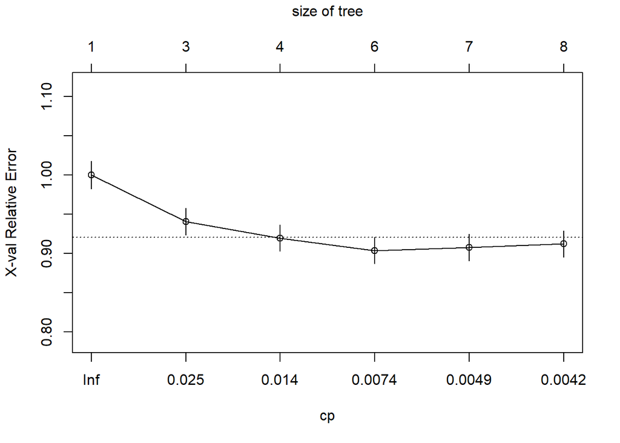

```r
plotcp(tree_medium)
```

The above plot suggests that 6 features are sufficient to accurately predict our categorical response variable at the cost of becoming too complex (already around cp = 0.0074).  
### Figure 4: Feature Importance

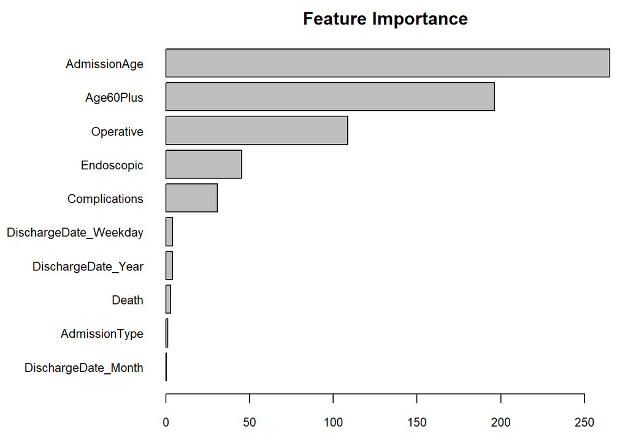

```r
par(mar=c(3, 9, 2, 1))
barplot(sort(tree_medium$variable.importance,decreasing = FALSE),
        main = "Feature Importance",
        las = 1,
        cex.names = .8,
        cex.axis = .8,
        horiz = TRUE)
```

Figure 4 above gives us a visual idea of the ratios the features have to each other. It is interesting to see that all three date engineered features makes it onto the plot, although they don’t have a significant effect on our outcome.

- CP = 0.004379
- nsplit = 6
- rel error = 0.8925159
- xerror = 0.9076433
- xstd = 0.0168636

Choosing the model with the lowest re-substitution rate does not guarantee the best table. Larger trees tend to have smaller re-substitution errors and they tend to have a bias. Large trees will put random variation in the predictions as they over fit outliers. Non-the-less, our model being inspected does not suffer from that, as it is only a medium sized tree and have in any case a fairly high re-substitution error of 0.89252. The cross validation error is 0.90764, which indicates that the cross validation effect is rather poor. However, the standard error, xstd = 0.016864 is fairly low.

### Support Vector Classifiers

The e1071 library offers an implementation of our stock standard Support Vector Machine implementation in the form of the svm function. The svm function offers a dizzying wealth of hyper parameters with which one can go absolutely gang-busters. For this exercise we’ll concentrate on only a few.  
First off, we’ll pin down the kernel = “linear”. The type parameter is by default set to C-classification due to the fact that our response variable is a binary factor. We also have the option of setting it to either nu-classification or one-classification. We’ll stick to the default.  
The next important parameter is the cost parameter, which offers us the option to specify a cost of constraint value. As the svm documentation suggests; it’s the ‘C’-constant of the regularization term in the Lagrange formulation. In layman’s terms - the C-constant is a trade off between the training error and the flatness of the solution. The larger the C-constant is the less the final training error. If it is too large we risk loosing the generalization properties of the classifier, because it will try and fit all of the training points as good as it can. This will include attempting to fit possible errors in the data set as well. Also, a large C value increases the training time. If C is small, then the classifier is flat. So we have to find a C value that keeps the error small but also generalizes well. The same goes for the epsilon parameter (epsilon controls the width of the epsilon insensitive zone, used to fit the training data.) There are several automated ways to “tune” these variables in order to find the most optimum combination. These methods includes cross-validation and grid-search functionality. Unfortunately, these methods require large computational power and therefore will not be exercised in this paper. Therefore, we’ll have to come up with a good guesstimate for our combination of C-constant and epsilon values. We’ll set C = 10 and epsilon = 0.1.

```r
library(e1071)
set.seed(1234)
svm_1=svm(LOS_cat~.,
          data    = train_set,
          kernel  = "linear",
          cost    = 10,
          epsilon = 0.1,
          scale   = FALSE,
          type    = "C-classification")
```

Let’s have a look at the model summary.

```r
summary(svm_1)
```

```
##
## Call:
## svm(formula = LOS_cat ~ ., data = train_set, kernel = "linear",
##     cost = 10, epsilon = 0.1, type = "C-classification", scale = FALSE)
##
##
## Parameters:
##    SVM-Type:  C-classification
##  SVM-Kernel:  linear
##        cost:  10
##
## Number of Support Vectors:  5634
##
##  ( 3221 2413 )
##
##
## Number of Classes:  2
##
## Levels:
##  0 1
```

The above summary suggest a staggering 5634 support vectors, which assist in defining the classification hyper plane. Is that good, or is it bad? I don’t know. The calculated coefficients of the svm are as follows:

```r
t(svm_1$coefs) %*% svm_1$SV
```

```
##           GenderF      GenderM  AdmissionAge   Age60Plus1      Death1
## [1,] -8.72652e-06 8.726521e-06 -2.146914e-05 0.0002416007 0.001318514
##      AdmissionTypeElective AdmissionTypeEmergency AdmissionTypeTransfer
## [1,]             -1.999932              -2.000095             -2.000116
##         Operative1 Complications1 Endoscopic1 DischargeDate_Year2012
## [1,] -5.713638e-05      -1.999979   -1.999997          -1.498089e-06
##      DischargeDate_Year2013 DischargeDate_Year2014 DischargeDate_Year2015
## [1,]           7.700351e-06           9.798443e-06            1.28131e-06
##      DischargeDate_Year2016 DischargeDate_Year2017 DischargeDate_Month2
## [1,]           7.905351e-06           2.814884e-06          1.10199e-05
##      DischargeDate_Month3 DischargeDate_Month4 DischargeDate_Month5
## [1,]         2.654063e-06        -1.064811e-05        -8.577233e-07
##      DischargeDate_Month6 DischargeDate_Month7 DischargeDate_Month8
## [1,]           1.4201e-05        -2.855224e-06         5.204672e-06
##      DischargeDate_Month9 DischargeDate_Month10 DischargeDate_Month11
## [1,]        -2.669098e-06          1.019953e-05           1.20847e-05
##      DischargeDate_Month12 DischargeDate_WeekdayMonday
## [1,]          1.495901e-05                7.905904e-06
##      DischargeDate_WeekdaySaturday DischargeDate_WeekdaySunday
## [1,]                  2.884701e-05                3.271069e-05
##      DischargeDate_WeekdayThursday DischargeDate_WeekdayTuesday
## [1,]                  1.034645e-05                 1.029017e-05
##      DischargeDate_WeekdayWednesday
## [1,]                   3.310945e-06
```

The e1071 package comes equipped with a tuning function, which is aptly called tune. The tune function is actually an automated hyper parameter tuning function as mentioned above. But, due to computational complexity we’ll only utilize it to find the error estimation for C = 10 and epsilon = 0.1.  
*The following code has been commented out due to the fact that it takes an enormous amount of time to run. The author had to run this code as a separate background job in RStudio in order to produce the results as displayed in the figure below the code.*

```r
#svm_tune = tune(svm,
#                LOS_cat ~ . ,
#                data    = train_set,
#                kernel  = "linear",
#                scale   = FALSE,
#                type    = "C-classification",
#                cost    = 10,
#                epsilon = 0.1)
```

Let’s see how the tune function performed in general.

```r
#summary(svm_tune)
```

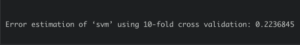

The other difference between tune and svm is that tune, by default, utilizes a 10-fold cross validation method. Non-the-less, the training error is 0.2236845.  
An error rate of 0.2236845 achieved for a cost = 10 and epsilon = 0.1 is not too bad. Decreasing the cost parameter will include more support vectors, because of a larger margin. This may or may not decrease the training error depending on what the effect of the epsilon = 0.1 is on the support vectors in the region of the hyper plane margin.

Now, let’s look at an alternative support vector classifier for which we’ll utilize a different kernel. We’ll discard with the linear kernel and replace it with kernel = radial.

```r
set.seed(1)
svm_radial <- svm(LOS_cat ~ . ,
                data      = train_set,
                cost      = 10,
                kernel    ='radial',
                gamma     = 1,
                coef0     = 1,
                scale     = FALSE,
                type      = 'C-classification',
                shrinking = FALSE)
```

```r
summary(svm_radial)
```

```
##
## Call:
## svm(formula = LOS_cat ~ ., data = train_set, cost = 10, kernel = "radial",
##     gamma = 1, coef0 = 1, type = "C-classification", shrinking = FALSE,
##     scale = FALSE)
##
##
## Parameters:
##    SVM-Type:  C-classification
##  SVM-Kernel:  radial
##        cost:  10
##
## Number of Support Vectors:  10128
##
##  ( 7638 2490 )
##
##
## Number of Classes:  2
##
## Levels:
##  0 1
```

```r
svm_radial_err <- svm_radial$tot.nSV
```

The radial kernel produces a hyper plane which is supported by 10128 support vectors. This is a significant increase in support vectors from the linear kernel implementation. The calculated coefficients of the svm with radial kernel are as follows:

```r
t(svm_radial$coefs) %*% svm_radial$SV
```

```
##        GenderF  GenderM AdmissionAge Age60Plus1    Death1
## [1,] -25.57755 25.57755    -22367.23  -432.5214 -6.796783
##      AdmissionTypeElective AdmissionTypeEmergency AdmissionTypeTransfer
## [1,]              9.864269               5.380315             -16.76312
##      Operative1 Complications1 Endoscopic1 DischargeDate_Year2012
## [1,]  -328.7197      -194.4047   -132.3492              -10.99059
##      DischargeDate_Year2013 DischargeDate_Year2014 DischargeDate_Year2015
## [1,]              -14.22897               55.13576              -3.512147
##      DischargeDate_Year2016 DischargeDate_Year2017 DischargeDate_Month2
## [1,]                59.5915               12.22683             22.21022
##      DischargeDate_Month3 DischargeDate_Month4 DischargeDate_Month5
## [1,]            -29.66518            -11.65264             3.755503
##      DischargeDate_Month6 DischargeDate_Month7 DischargeDate_Month8
## [1,]            -11.38685            -15.35463             6.676831
##      DischargeDate_Month9 DischargeDate_Month10 DischargeDate_Month11
## [1,]            -11.30463              21.88923              26.22187
##      DischargeDate_Month12 DischargeDate_WeekdayMonday
## [1,]              21.90171                    -22.3846
##      DischargeDate_WeekdaySaturday DischargeDate_WeekdaySunday
## [1,]                      71.18845                    83.65958
##      DischargeDate_WeekdayThursday DischargeDate_WeekdayTuesday
## [1,]                      8.063863                    -31.17331
##      DischargeDate_WeekdayWednesday
## [1,]                      -27.99791
```

The coefficients for all the features differ significantly from the svm with kernel = “linear”. With the radial kernel the importance of the features are very similar to the ranking of the feature for the decision tree. The big difference in feature importance between the linear and the radial kernel implementations are that weight assigned to the AdmissionAge feature.

We, again, utilize the tune function to determine the performance error on the training data.

```r
set.seed(1)
svm_radial_tune = tune(svm,
                LOS_cat ~ . ,
                data    = train_set,
                cost      = 10,
                kernel    ='radial',
                gamma     = 1,
                coef0     = 1,
                scale     = FALSE,
                type      = 'C-classification',
                shrinking = FALSE)
```

```r
summary(svm_radial_tune)
```

```
##
## Error estimation of 'svm' using 10-fold cross validation: 0.2486216
```

The error for kernel = “radial”, 0.2486216 is slightly worse than the svm with kernel = “linear”. The radial kernel support vector machines is a good approach when the data is not linearly seperable. The idea behind generating non-linear decision boundaries is that we need to do some nonlinear transformations on the features, which transforms them into a higher dimensional space. We do this non-linear transformation using the Kernel trick. Same as with the linear kernel there are a number of parameters that we can tune to optimise the radial kernel. However, manipulating the feature space into higher dimensions are outside the scope of this paper but, remains an area of interest to the author. Also, the area of research on the realtionship between the radial base function and the semi-Lagrangian seems to be buzzing.

### Time to do some predicitons

First, let’s evaluate the decision tree model.

```r
#PREDICTION
set.seed(1)
pre <- predict(tree_medium, test_set, type="class")
tab <- table(pre, test_set$LOS_cat)
accuracy <- sum(diag(tab))/sum(tab); accuracy
```

```
## [1] 0.7869281
```

```r
error <- 0
error <- error + (1 - accuracy); error
```

```
## [1] 0.2130719
```

For the medium_tree model the error rate, against the test set, is 0.2130719.

Second, let’s evaluate the first support vector model (kernel = linear, cost = 10, epsilon = 0.1).

```r
#PREDICTION
set.seed(1)
pre_svm <- predict(svm_1, test_set, type="class")
tab_svm <- table(pre_svm, test_set$LOS_cat)
accuracy_svm <- sum(diag(tab_svm))/sum(tab_svm); accuracy_svm
```

```
## [1] 0.7740741
```

```r
error_svm <- 0
error_svm <- error_svm + (1 - accuracy_svm); error_svm
```

```
## [1] 0.2259259
```

For the svm_1 model the error rate, against the test set, is 0.2259259.

```r
#PREDICTION
set.seed(1)
pre_svm_2 <- predict(svm_radial, test_set, type="class")
tab_svm_2 <- table(pre_svm_2, test_set$LOS_cat)
accuracy_svm_2 <- sum(diag(tab_svm_2))/sum(tab_svm_2); accuracy_svm_2
```

```
## [1] 0.7488017
```

```r
error_svm_2 <- 0
error_svm_2 <- error_svm_2 + (1 - accuracy_svm_2); error_svm_2
```

```
## [1] 0.2511983
```